# Poverty and Test Performance in New York Public Schools

Lilibet Trautman

## Question

**What can data tell us about the relationship between poverty and test performance in New York public schools?**

I combined two datasets: school-level test scores and lunch data from the NYS Department of Education, and county-level poverty data from the US Census (ACS). Because the state test changes over time, all scores are standardized to a **z-score within each year**, so a value of 0 means “average for that year” and +1 means “one standard deviation above average.”

## Question 1: Do low, medium, and high poverty areas differ in test performance?

Counties were split into equal thirds (tertiles) by their poverty rate, so each group holds roughly the same number of counties.

```
## # A tibble: 3 × 5
##   poverty_group n_schools avg_z_math avg_z_ela avg_free_red
##   <chr>             <int>      <dbl>     <dbl>        <dbl>
## 1 high              12351    -0.224    -0.272         0.695
## 2 low                9136     0.333     0.402         0.346
## 3 medium             7063    -0.0184   -0.0191        0.500
```

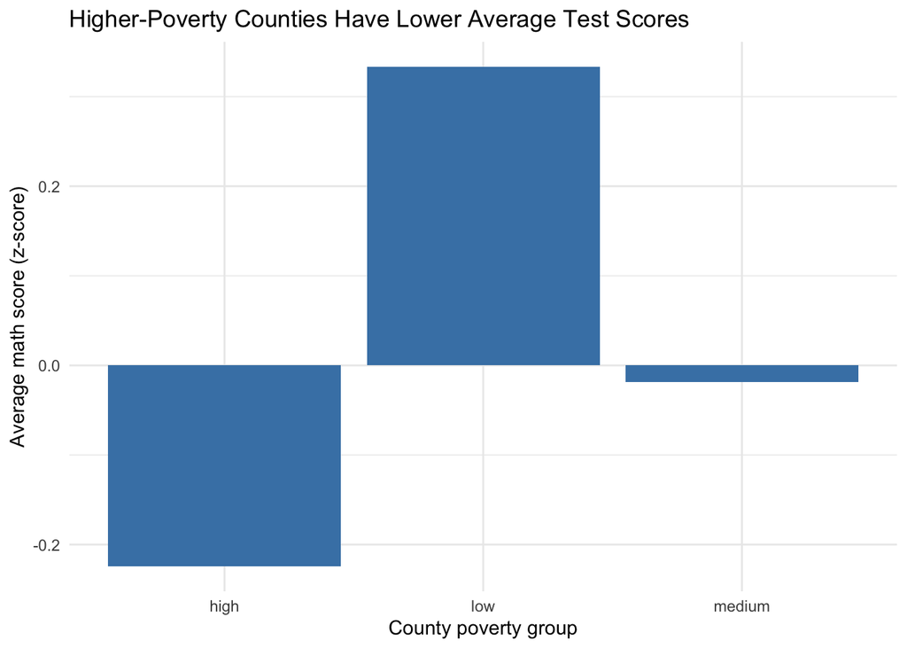

**Takeaway:** Test performance falls as county poverty rises. High-poverty counties score below the state average; low-poverty counties score above it.

## Question 2: Has this relationship changed over time?

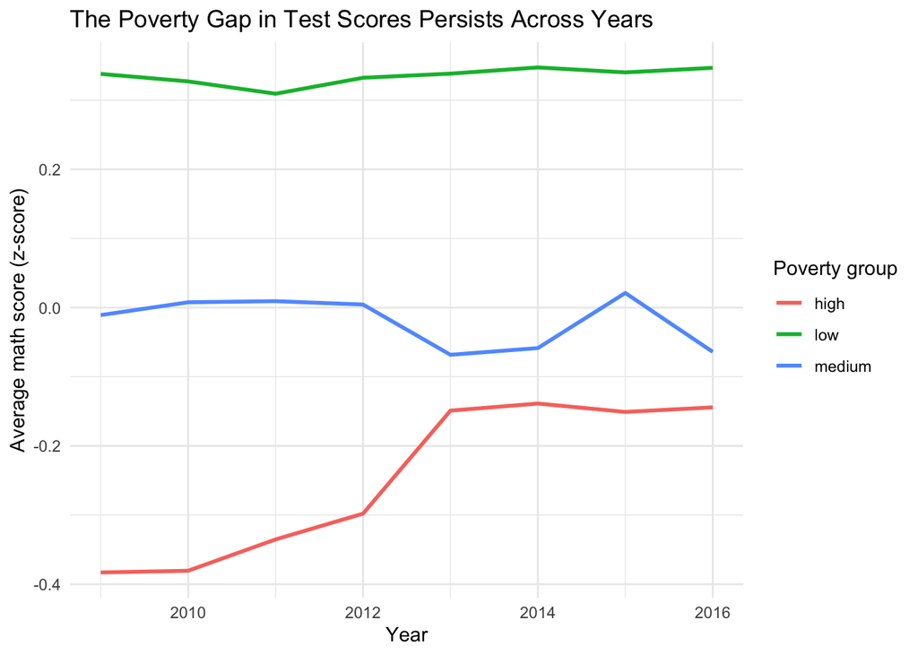

## Question 3: Is the relationship moderated by access to free/reduced lunch?

At the school level, the share of students on free/reduced lunch (a direct poverty measure) has a clear negative relationship with test scores.

[figure not shown]

```
## # A tibble: 1 × 1
##   correlation
##         <dbl>
## 1      -0.608
```

**Takeaway:** Free/reduced lunch is itself a strong marker of disadvantage and moves with lower scores. Rather than softening the poverty effect, it reinforces the same story from the school side that the county poverty data shows from the area side.

## Caveats

- ACS county data only covers 2009-2016, so schools in 2008 and 2017 have no poverty match and are dropped from the poverty-group analyses.
- This is correlation, not causation – poverty does not directly *cause* lower scores; it is bound up with many other factors (funding, resources, etc.).